# Contentious Actors on Social Media and Implications for Advocacy in Digital Democracy

## Allison Koh

PhD Researcher

[figure not shown]

Department of Political Economy  
King’s College London  
July 4, 2023

## Background

Education 🎓

- PhD in Political Science at the Hertie School, exp. 2023
- MPP in Policy Analysis at the Hertie School, 2020
- BSc in Economics and Asian Studies at Tulane University, 2016

Methods Experience 📊

- Survey data
- Observational/Quasi-experimental research designs
- Computational methods
- Consulting

Affiliations 👥

[figure not shown]

[figure not shown]

[figure not shown]

# Current Research

Pro-Government Social Media on the Global Stage

Image source: Meta

## Pro-Government Social Media on the Global Stage

[figure not shown]

[figure not shown]

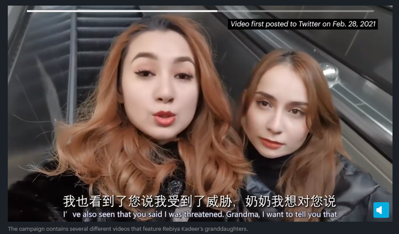

- States are increasingly integrating foreign platforms into their strategies for controlling information flows beyond their borders.
- Overarching and sub-RQs

## How do authoritarian regimes use social media to shape the global public sphere?

They can leverage facets of national identity to discredit diaspora regime critics.

**Hypotheses**

- **Gender**: Women easier to attack
- **Language** of the “oppressor”

**Method** for stance detection

- Multilingual BERT + Active Learning

**Case study** on Pro-CCP Twitter’s communication with Uyghur activists-in-exile

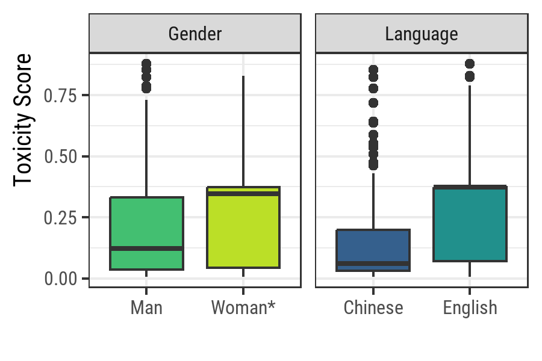

## How do authoritarian regimes use social media to shape the global public sphere?

They benefit from platform policies that expand the reach of state actors globally.

[figure not shown]

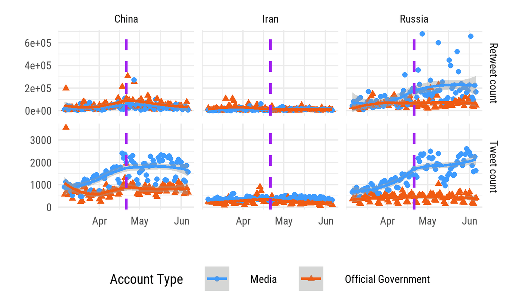

## Main Takeaways

- Autocracies and their proxies are capable of manipulating social media to curtail the global public sphere in their favor—*even on platforms where their governments do not have direct provision over content moderation*.

# Contributions to ADVODID

LGBTQ+ and Anti-LGBTQ+ Advocacy in Digital Democracy

[figure not shown]

[figure not shown]

[figure not shown]

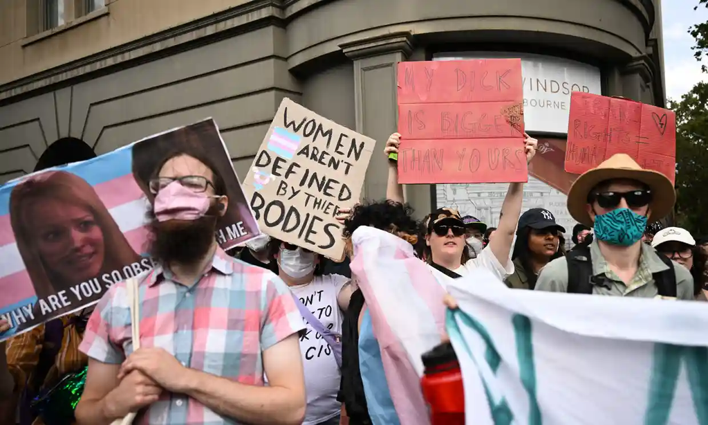

[figure not shown]

## [Anti-]LGBTQ+ Advocacy $\leftrightarrow$ Politics

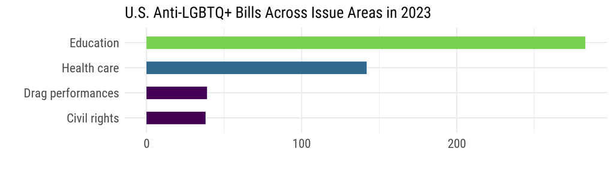

Data Source: American Civil Liberties Union

## Research Questions

### **Use**

- How are openly LGBTQ+ politicians represented in online and offline debates about LGBTQ+ policy?
- Are some interest group types more responsive to online debates about LGBTQ+ discourse compared to others?

### **Impact**

- What are the effects of politicians’ social media discussions around LGBTQ+ issues on offline and offline protest participation?
- Compared to anti-LGBTQ+ groups, are pro-LGBTQ+ groups more likely to respond to social media calls to action?

### **Democratic Consequences**

- What is the relationship between citizens’ participation in anti-LGBTQ+ discourse on social media and support for right-wing policies?
- How does a government’s technical capacity factor into politicians’ involvement in online discussions around LGBTQ+ politics?

## Collaborations at Kings College London

### ADVODID

- Theory Development ↔︎️ Computational Methods

### Department of Political Economy

- QPE

- Political theory group

# Thank you!

koh@hertie-school.org

https://allisonkoh.github.io/

@allisonwkoh@mastodon.social🎓

@allisonwkoh@fosstodon.org📊

@allisonkoh_

## References

Ritholtz, Samuel, Allison Koh, and Anita Gohdes. 2022. “Fanning the Flames of Hate: The Transnational Diffusion of Online Anti-LGBT+ Rhetoric and Offline Mobilisation.” *GNET*.